# Ordinal Logit Example

Mary Collins

August 28, 2015

### Researchers are interested in hydrofracking risk perception.

**Data background**: 2500 US respondents took a ~30 web-based environmental risk perception survey. Due to survey length, not all respondents were asked all questions.

**Independent variables**: political ideology (liberal – conservative), 3-class political party identification, environmental values index (NEP battery), income, gender, race (white vs. non-white).

### Access Data

Pull in full datafile (n=2500), select variables of interest.

```r
rm(list=ls())
dat <- read.dta("~/Dropbox/ERP2/Mary's Analysis for SfAA/ERP2_Updated 16 Feb 2015_Stata11forMary.dta")
```

```r
dat <- data.frame(dat$ac_fracking,
                  dat$liberal, dat$democrat, dat$nepindex,
                  dat$income, dat$male, dat$white)
colnames(dat)[1] <- "frack"
colnames(dat)[2] <- "liberal"
colnames(dat)[3] <- "dem"
colnames(dat)[4] <- "nep"
colnames(dat)[5] <- "income"
colnames(dat)[6] <- "male"
colnames(dat)[7] <- "white"
```

### JAGS Model Statement

Modeling fracking acceptability using an ordered logit.

General strategy: create the straight forward linear combination, then dive into inverse logit and take advantage of CDF to get the slices of the distribution that we’re interested in. More details commented in the code below.

```r
modelstring="
 model{
  for(i in 1:N){  ## loop over observations
    ## form the linear predictor (no intercept)
    mu[i] <-  x[i,1]*beta[1] +
x[i,2]*beta[2] +
x[i,3]*beta[3] +
x[i,4]*beta[4] +
x[i,5]*beta[5] +
x[i,6]*beta[6]

    ## cumulative logistic probabilities
    logit(Q[i,1]) <- tau[1]-mu[i] # because invLogit(-x) = 1-invLogit(x); see also Gelman and Hill for definition.

      p[i,1] <- Q[i,1] #prob of being to the left of the first tau

      for(j in 2:4){
      logit(Q[i,j]) <- tau[j]-mu[i]
      ## trick to get slice of the cdf we need
      p[i,j] <- Q[i,j] - Q[i,j-1]
    }
    p[i,5] <- 1 - Q[i,4] #prob of being greater than the last tau

    y[i] ~ dcat(p[i,1:5])  ## y (data come in) is a descrete RV with 5 values whose prob's are given by p

  }

  ## priors over betas
  beta[1:6] ~ dmnorm(b0[],B0[,])

  ## priors for thresholds
  for(j in 1:4){
    tau0[j] ~ dnorm(0, .01)
  }

  tau[1:4] <- sort(tau0)  ## Just put in order
}






"
```

Some data prep is needed:

```r
dat1 <- cbind(dat$frack,
              dat$liberal,dat$dem, dat$nep,
              dat$income,dat$male,dat$white) # sometimes easier to work with a matrix when data

dat1[,6] <- replace(dat1[,6], dat1[,6] == 1, 0) #make 0 = Female
dat1[,6] <- replace(dat1[,6], dat1[,6] == 2, 1) #make 1 = Male

dat1[,7] <- replace(dat1[,7], dat1[,7] == 1, 0) #make 0 = NonWhite
dat1[,7] <- replace(dat1[,7], dat1[,7] == 2, 1) #make 1 = White

dat1 <- dat1[complete.cases(dat1),]
#dat1 <- dat1[sample(1:nrow(dat1), 100, replace=FALSE),]

#center data
dat1[,2] <- dat1[,2] - mean(dat1[,2])
dat1[,3] <- dat1[,3] - mean(dat1[,3])
dat1[,4] <- dat1[,4] - mean(dat1[,4])
dat1[,5] <- dat1[,5] - mean(dat1[,5])
dat1[,6] <- dat1[,6] - mean(dat1[,6])
dat1[,7] <- dat1[,7] - mean(dat1[,7])
```

Setup for JAGS

- Y needs to be descrete.
- Priors for 6 betas
- Generate some inits
- Spec number of samples, burn in and samples for posterior

```r
data <- list(y=round(dat1[,1])+1,
             N=nrow(dat1),
             x=cbind(dat1[,2:7]),
             b0=rep(0,6), #1 dim vector for mu
             B0=diag(.01,6) # square co-variance matrix
             )

inits <- list(list(beta=runif(6),
                   tau0=runif(4,-2,2)),
              list(beta=runif(6),
                   tau0=runif(4,-2,2)),
              list(beta=runif(6),
                   tau0=runif(4,-2,2))
)
n.adapt=10000
n.update = 10000
n.iter = 30000
n.chains = 3
```

Thin every 5th.

```
##    Graph Size: 11430
##
```

Summary info and plots

```
##
## Iterations = 20005:50000
## Thinning interval = 5
## Number of chains = 3
## Sample size per chain = 6000
##
## 1. Empirical mean and standard deviation for each variable,
##    plus standard error of the mean:
##
##             Mean      SD  Naive SE Time-series SE
## beta[1] -0.24442 0.10472 0.0007805      0.0022592
## beta[2] -0.09936 0.13928 0.0010382      0.0032148
## beta[3] -0.41648 0.03205 0.0002389      0.0004782
## beta[4]  0.07219 0.02592 0.0001932      0.0003065
## beta[5]  0.32922 0.16777 0.0012505      0.0040435
## beta[6] -0.13303 0.18464 0.0013762      0.0046891
## tau[1]  -1.38906 0.12037 0.0008972      0.0011606
## tau[2]  -0.24684 0.10857 0.0008092      0.0009322
## tau[3]   0.90582 0.11601 0.0008647      0.0010369
## tau[4]   2.52079 0.15460 0.0011523      0.0015903
##
## 2. Quantiles for each variable:
##
##              2.5%      25%      50%       75%    97.5%
## beta[1] -0.451756 -0.31552 -0.24438 -0.173936 -0.04318
## beta[2] -0.375133 -0.19432 -0.09711 -0.003795  0.16794
## beta[3] -0.479988 -0.43831 -0.41621 -0.394505 -0.35480
## beta[4]  0.021750  0.05464  0.07226  0.089714  0.12279
## beta[5]  0.001496  0.21413  0.32867  0.444787  0.65746
## beta[6] -0.499471 -0.25464 -0.13270 -0.010493  0.23253
## tau[1]  -1.627679 -1.47008 -1.38813 -1.306259 -1.15640
## tau[2]  -0.459441 -0.31981 -0.24728 -0.174075 -0.03220
## tau[3]   0.681737  0.82859  0.90508  0.982929  1.13083
## tau[4]   2.227684  2.41413  2.51925  2.623825  2.83216
```

```
## Potential scale reduction factors:
##
##         Point est. Upper C.I.
## beta[1]          1       1.00
## beta[2]          1       1.01
## beta[3]          1       1.00
## beta[4]          1       1.00
## beta[5]          1       1.01
## beta[6]          1       1.00
## tau[1]           1       1.00
## tau[2]           1       1.00
## tau[3]           1       1.00
## tau[4]           1       1.00
##
## Multivariate psrf
##
## 1
```

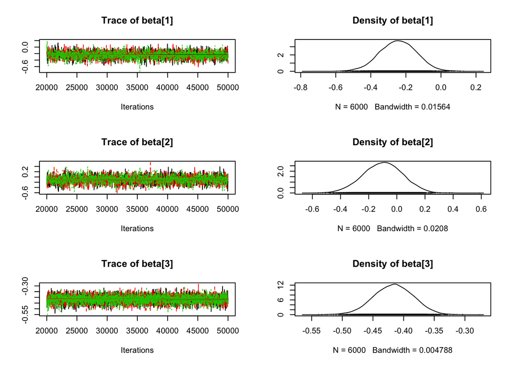

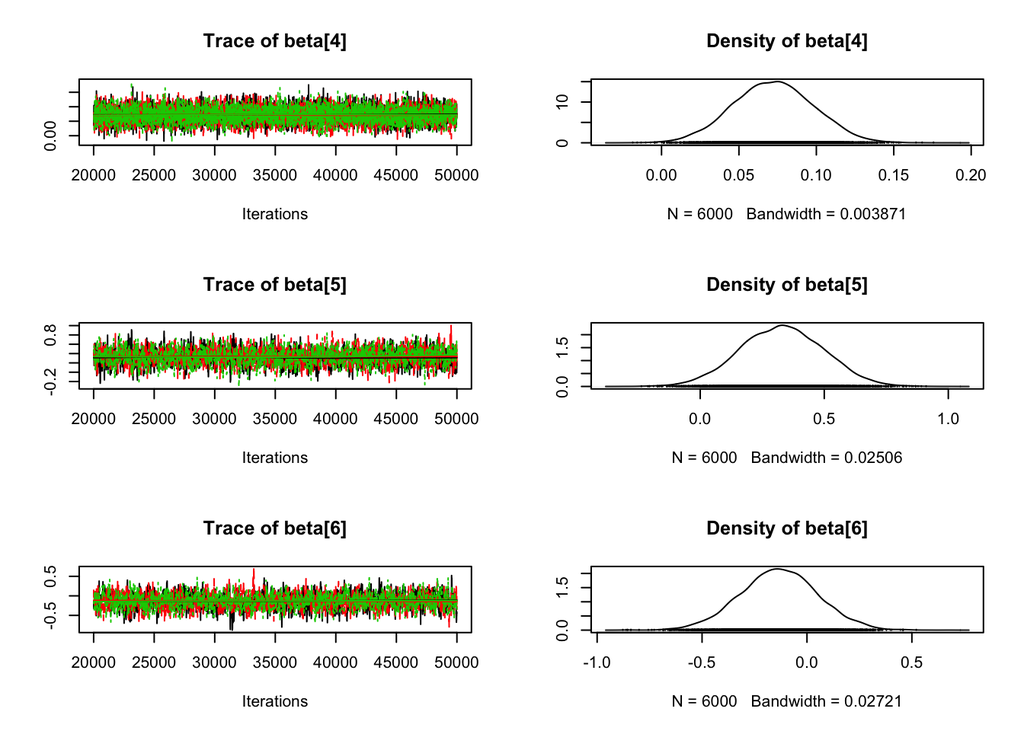

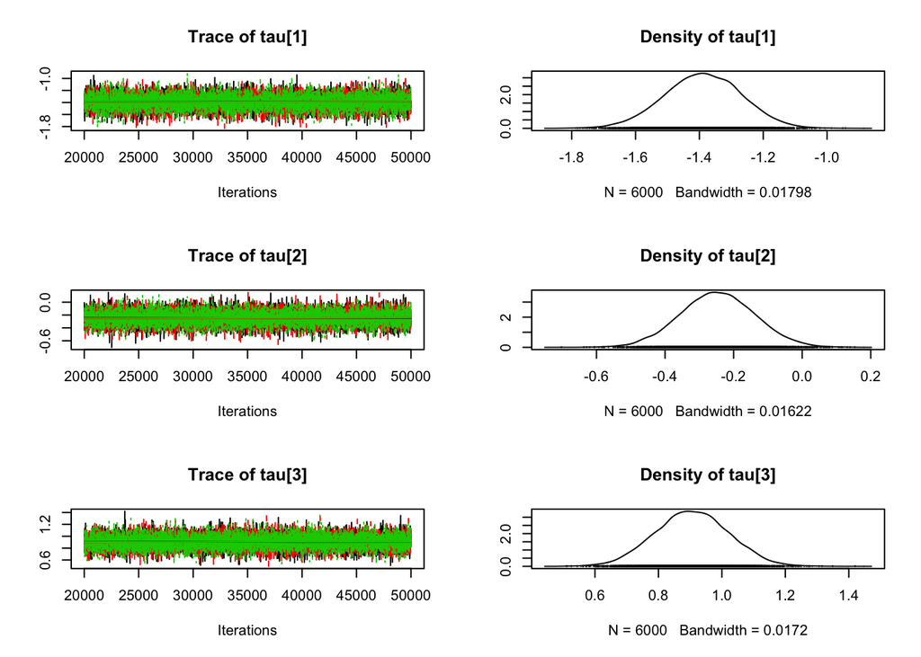

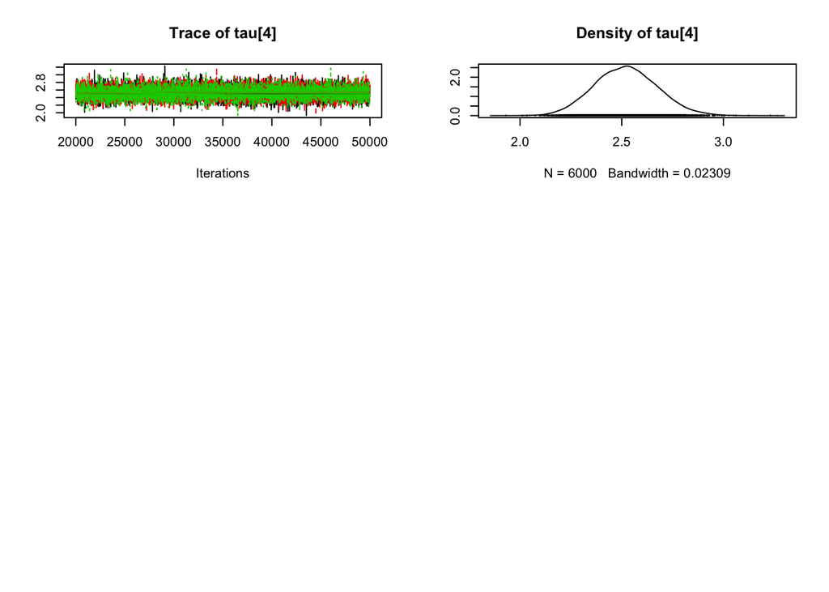

Prior plots

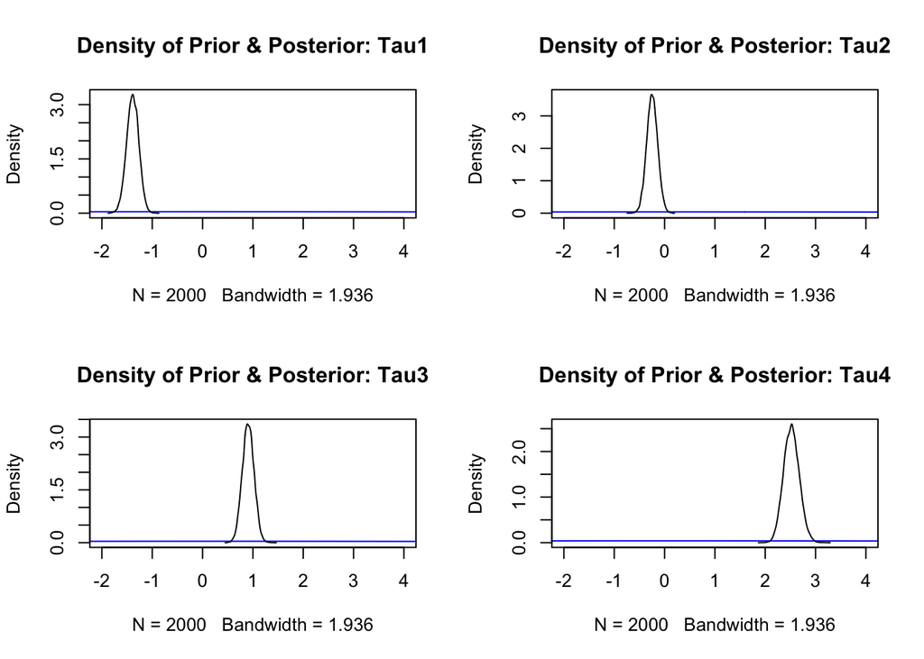

```r
par(mfrow=c(2,2))

samples = as.data.frame(rbind(cs[[1]], cs[[2]], cs[[3]]))
prior_tau <- rnorm(2000, 0, (1/0.01)^0.5)
prior_beta <- rnorm(2000, 0, (1/0.01)^0.5)

t1max <- max(density(samples[,7])[[2]])
t2max <- max(density(samples[,8])[[2]])
t3max <- max(density(samples[,9])[[2]])
t4max <- max(density(samples[,10])[[2]])


plot(density(prior_tau), col="blue", main = "Density of Prior & Posterior: Tau1", ylim = c(0,t1max), xlim = c(-2,4))
lines(density(samples[,7]))
plot(density(prior_tau), col="blue", main = "Density of Prior & Posterior: Tau2", ylim = c(0,t2max), xlim = c(-2,4))
lines(density(samples[,8]))
plot(density(prior_tau), col="blue", main = "Density of Prior & Posterior: Tau3", ylim = c(0,t3max), xlim = c(-2,4))
lines(density(samples[,9]))
plot(density(prior_tau), col="blue", main = "Density of Prior & Posterior: Tau4", ylim = c(0,t4max), xlim = c(-2,4))
lines(density(samples[,10]))
```

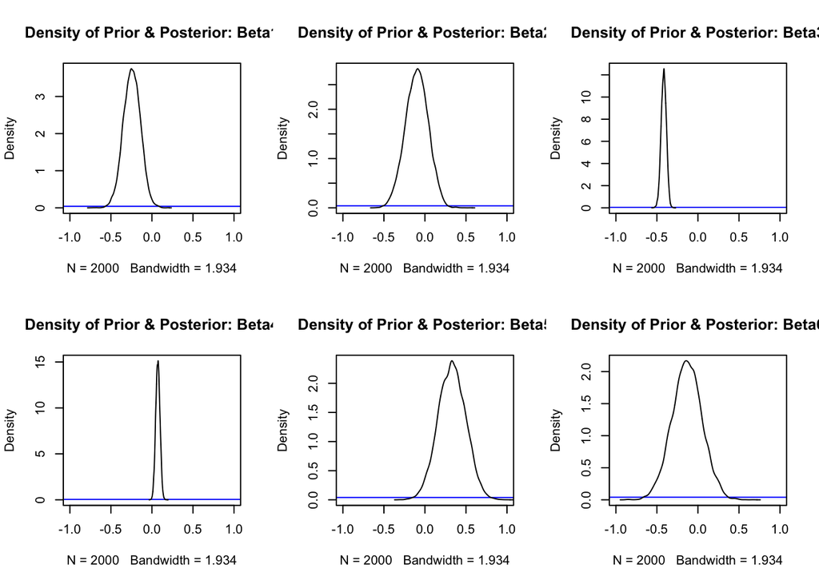

```r
par(mfrow=c(2,3))

b1max <- max(density(samples[,1])[[2]])
b2max <- max(density(samples[,2])[[2]])
b3max <- max(density(samples[,3])[[2]])
b4max <- max(density(samples[,4])[[2]])
b5max <- max(density(samples[,5])[[2]])
b6max <- max(density(samples[,6])[[2]])

plot(density(prior_beta), col="blue", main = "Density of Prior & Posterior: Beta1", ylim = c(0,b1max), xlim = c(-1,1))
lines(density(samples[,1]))
plot(density(prior_beta), col="blue", main = "Density of Prior & Posterior: Beta2", ylim = c(0,b2max), xlim = c(-1,1))
lines(density(samples[,2]))
plot(density(prior_beta), col="blue", main = "Density of Prior & Posterior: Beta3", ylim = c(0,b3max), xlim = c(-1,1))
lines(density(samples[,3]))
plot(density(prior_beta), col="blue", main = "Density of Prior & Posterior: Beta4", ylim = c(0,b4max), xlim = c(-1,1))
lines(density(samples[,4]))
plot(density(prior_beta), col="blue", main = "Density of Prior & Posterior: Beta5", ylim = c(0,b5max), xlim = c(-1,1))
lines(density(samples[,5]))
plot(density(prior_beta), col="blue", main = "Density of Prior & Posterior: Beta6", ylim = c(0,b6max), xlim = c(-1,1))
lines(density(samples[,6]))
```

Next I want to look at predicted probabilities for by values of political ideology and environmental concern.

```r
dat1 <- as.data.frame(dat1)

csI <- as.data.frame(rbind(cs[[1]], cs[[2]],cs[[3]]))
csI.mcmc <- as.mcmc(csI)
csI.mat <- as.matrix(csI.mcmc)
csI.mat.df <- as.data.frame(csI.mat)
b <- csI.mat.df[ , 1:6] # grab all the betas

liberal <- data$x[,1] # predictions for ideology
x.liberal <- seq(min(liberal),max(liberal),.05)

dem3 <- data$x[,2]
new.dem3 <- rep(median(dem3), length(x.liberal))
nep <- data$x[,3]
new.nep <- rep(median(nep), length(x.liberal))
income <- data$x[,4]
new.income <- rep(median(income), length(x.liberal))
male <- data$x[,5]
new.male <- rep(median(male), length(x.liberal))
white <- data$x[,6]
new.white <- rep(median(white), length(x.liberal))

sim <- cbind(x.liberal, new.dem3,new.nep,new.income,new.male,new.white)

Xb <- t(sim %*% t(b))
t4 <- mean(csI.mat.df[,7])
t3 <- mean(csI.mat.df[,8])
t2 <- mean(csI.mat.df[,9])

csI.pp <- exp(Xb-t3)/(1+exp(Xb-t3))

csI.ci <- apply(csI.pp, 2, quantile, probs=c(.025,.975)) ## apply(a, b, c): apply function (c) to object(a), by(b: 1 for row, 2 for column)

# Get mean predictions over the n (from JAGS iterations) sampled values of b
mean.csI.pp <- apply(csI.pp, 2, mean)
mean.csI.ci <- apply(csI.ci, 2, quantile, probs=c(.025,.975))
```

Want to make plots of predicted probabilities for NEP

```r
dat1 <- as.data.frame(dat1)
csN.df <- as.data.frame(rbind(cs[[1]], cs[[2]],cs[[3]]))
csN.mcmc <- as.mcmc(csN.df)
csN.mat <- as.matrix(csN.mcmc)
csN.mat.df <- as.data.frame(csN.mat)
b <- csN.mat.df[ , 1:6]

nep <- data$x[,3]
x.nep <- seq(min(nep),max(nep),.2)

liberal <- data$x[,1]
new.liberal <- rep(median(liberal), length(x.nep))
dem3 <- data$x[,2]
new.dem3 <- rep(median(dem3), length(x.nep))
income <- data$x[,4]
new.income <- rep(median(income), length(x.nep))
male <- data$x[,5]
new.male <- rep(median(male), length(x.nep))
white <- data$x[,6]
new.white <- rep(median(white), length(x.nep))

sim <- cbind(new.liberal, new.dem3,x.nep,new.income,new.male,new.white)

Xb <- t(sim %*% t(b))
t4 <- mean(csN.mat.df[,7])
t3 <- mean(csN.mat.df[,8])
t2 <- mean(csN.mat.df[,9])

csN.pp <- exp(Xb-t3)/(1+exp(Xb-t3))

csN.ci <- apply(csN.pp, 2, quantile, probs=c(.025,.975)) ## apply(a, b, c): apply function (c) to object(a), by(b: 1 for row, 2 for column)

# Get mean predictions over the n (from JAGS iterations) sampled values of b
mean.csN.pp <- apply(csN.pp, 2, mean)
mean.csN.ci <- apply(csN.ci, 2, quantile, probs=c(.025,.975))
```

[figure not shown]